# Aprendizaje_A_NS_Parte2a

**Objetivos:**

- Implementar los modelos vistos en clase tanŧo de regresión como de claificación sobre el data set de galaxias
- Realizar un análisis de los resultados obtenidos que cada una de las pruebas
- Comparar la performance y seleccionar el mejor modelo tanto para tabla como para imágenes

# Paquetes necesarios

```python
import numpy as np
import seaborn as sns
import matplotlib.pyplot as plt
import pandas as pd
```

```python
%matplotlib inline
plt.rcParams["figure.figsize"] = (10,6)
```

| objID | ra | dec | modelMag_u | modelMag_g | modelMag_r | modelMag_i | modelMag_z | petroR90_r | Color | elliptical | spiral | uncertain | distancia_L | Mag_abs |
| --- | --- | --- | --- | --- | --- | --- | --- | --- | --- | --- | --- | --- | --- | --- |
| 1.237674e+18 | 119.822479 | 42.008528 | 17.36539 | 15.46586 | 14.54658 | 14.07490 | 13.69937 | 18.121160 | -2.818807 | 1.0 | 0.0 | 0.0 | 135.131916 | -21.191136 |
| 1.237674e+18 | 118.185239 | 33.699089 | 19.95136 | 18.35397 | 17.54043 | 17.05026 | 16.71222 | 3.657189 | -2.410933 | 0.0 | 0.0 | 1.0 | 153.893111 | -18.473102 |

```
(32623, 14)
```

```
'distribución de las variables físicas de las galaxias'
```

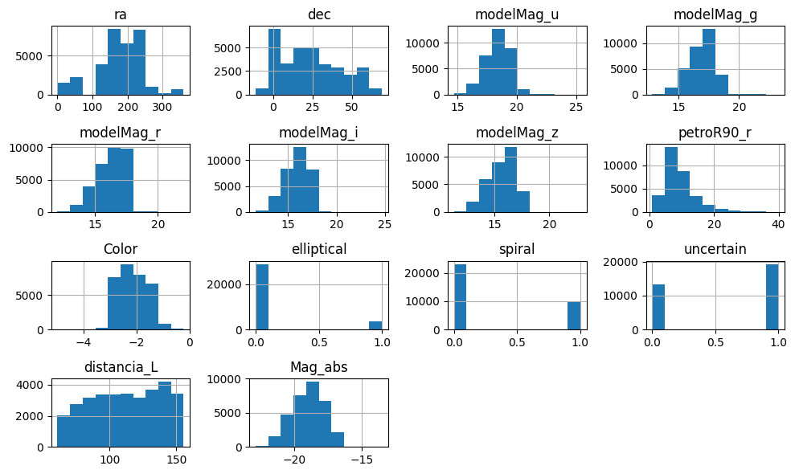

```python
dataset = pd.read_csv('galaxias_2.csv', index_col=['objID'])
display(dataset.head(2))
display(dataset.shape)
display('distribución de las variables físicas de las galaxias')
dataset.hist()
plt.tight_layout()
```

```python
dataset.info()
```

```
<class 'pandas.core.frame.DataFrame'>
Float64Index: 32623 entries, 1.23767370557974e+18 to 1.23765546806247e+18
Data columns (total 14 columns):
 #   Column       Non-Null Count  Dtype
---  ------       --------------  -----
 0   ra           32623 non-null  float64
 1   dec          32623 non-null  float64
 2   modelMag_u   32623 non-null  float64
 3   modelMag_g   32623 non-null  float64
 4   modelMag_r   32623 non-null  float64
 5   modelMag_i   32623 non-null  float64
 6   modelMag_z   32623 non-null  float64
 7   petroR90_r   32623 non-null  float64
 8   Color        32623 non-null  float64
 9   elliptical   32623 non-null  float64
 10  spiral       32623 non-null  float64
 11  uncertain    32623 non-null  float64
 12  distancia_L  32623 non-null  float64
 13  Mag_abs      32623 non-null  float64
dtypes: float64(14)
memory usage: 3.7 MB
```

```python
galaxias_curadas = pd.read_csv('galaxias_curadas', index_col=['objID'])
galaxias_curadas
```

| objID | ra | dec | modelMag_u | modelMag_g | modelMag_r | modelMag_i | modelMag_z | petroR90_r | z | Color | elliptical | spiral | uncertain | clase |
| --- | --- | --- | --- | --- | --- | --- | --- | --- | --- | --- | --- | --- | --- | --- |
| 1,23765119242489E+018 | 116.519097 | 39.886407 | 0.429235 | 0.429182 | 0.436968 | 0.477502 | 0.510150 | 0.000096 | 0.717351 | 0.875127 | 0 | 1 | 0 | S |
| 1,23765149575578E+018 | 116.451900 | 41.421270 | 0.477759 | 0.378912 | 0.343713 | 0.364403 | 0.375489 | 0.000113 | 0.673681 | 0.778513 | 0 | 0 | 1 | I |
| 1,23767370611537E+018 | 115.946713 | 41.918877 | 0.538662 | 0.504448 | 0.503749 | 0.549035 | 0.596528 | 0.000133 | 0.146169 | 0.865335 | 0 | 0 | 1 | I |
| 1,2376737066523E+018 | 116.051943 | 42.287231 | 0.916855 | 0.759424 | 0.753877 | 0.922012 | 0.829910 | 0.000009 | 0.637896 | 0.846001 | 0 | 0 | 1 | I |
| 1,23765127349266E+018 | 117.287392 | 43.434782 | 0.621757 | 0.566901 | 0.552328 | 0.601514 | 0.637512 | 0.000149 | 0.753031 | 0.856296 | 0 | 0 | 1 | I |
| ... | ... | ... | ... | ... | ... | ... | ... | ... | ... | ... | ... | ... | ... | ... |
| 1,23766556715083E+018 | 231.130092 | 18.628772 | 0.504471 | 0.417123 | 0.384380 | 0.409592 | 0.424851 | 0.000116 | 0.308971 | 0.794420 | 1 | 0 | 0 | E |
| 1,23765495320163E+018 | 245.132716 | 49.797424 | 0.468815 | 0.464653 | 0.473307 | 0.522812 | 0.557913 | 0.000104 | 0.694151 | 0.880735 | 0 | 0 | 1 | I |
| 1,23765494945271E+018 | 245.038742 | 50.552353 | 0.684248 | 0.539501 | 0.488954 | 0.515780 | 0.530817 | 0.000034 | 0.953935 | 0.774471 | 0 | 0 | 1 | I |
| 1,23765153764514E+018 | 219.313588 | 62.338577 | 0.566541 | 0.536782 | 0.536688 | 0.589254 | 0.632478 | 0.000053 | 0.562806 | 0.874798 | 0 | 0 | 1 | I |
| 1,237655744025E+018 | 239.043213 | 4.601942 | 0.586866 | 0.495828 | 0.482134 | 0.526006 | 0.576325 | 0.000160 | 0.471480 | 0.822695 | 0 | 1 | 0 | S |

56545 rows × 14 columns

**Cree y guarde un nuevo dataset a partir de la información del dataset preprocesado/curado por ud y las nuevas variables fisicas proporcionadas en dataset_2 (Mag_abs y distancia_L)**

# Analisis de Datos

```python
def galaxy_morf(row):
    if row["elliptical"]:
        return "E"
    elif row["spiral"]:
        return "S"
    else:
        return "I"
```

```python
dataset["Type"] = dataset.apply(galaxy_morf, axis=1)
```

```python
dataset.columns
```

```
Index(['ra', 'dec', 'modelMag_u', 'modelMag_g', 'modelMag_r', 'modelMag_i',
       'modelMag_z', 'petroR90_r', 'Color', 'elliptical', 'spiral',
       'uncertain', 'distancia_L', 'Mag_abs', 'Type'],
      dtype='object')
```

```python
data_cl = dataset.loc[~(dataset.index.astype(str).duplicated(keep="first"))]
data_cl.shape
```

```
(18007, 15)
```

```python
data_cl.info()
```

```
<class 'pandas.core.frame.DataFrame'>
Float64Index: 18007 entries, 1.23767370557974e+18 to 1.23766554782479e+18
Data columns (total 15 columns):
 #   Column       Non-Null Count  Dtype
---  ------       --------------  -----
 0   ra           18007 non-null  float64
 1   dec          18007 non-null  float64
 2   modelMag_u   18007 non-null  float64
 3   modelMag_g   18007 non-null  float64
 4   modelMag_r   18007 non-null  float64
 5   modelMag_i   18007 non-null  float64
 6   modelMag_z   18007 non-null  float64
 7   petroR90_r   18007 non-null  float64
 8   Color        18007 non-null  float64
 9   elliptical   18007 non-null  float64
 10  spiral       18007 non-null  float64
 11  uncertain    18007 non-null  float64
 12  distancia_L  18007 non-null  float64
 13  Mag_abs      18007 non-null  float64
 14  Type         18007 non-null  object
dtypes: float64(14), object(1)
memory usage: 2.2+ MB
```

```python
data_cl
```

| objID | ra | dec | modelMag_u | modelMag_g | modelMag_r | modelMag_i | modelMag_z | petroR90_r | Color | elliptical | spiral | uncertain | distancia_L | Mag_abs | Type |
| --- | --- | --- | --- | --- | --- | --- | --- | --- | --- | --- | --- | --- | --- | --- | --- |
| 1.237674e+18 | 119.822479 | 42.008528 | 17.36539 | 15.46586 | 14.54658 | 14.07490 | 13.69937 | 18.121160 | -2.818807 | 1.0 | 0.0 | 0.0 | 135.131916 | -21.191136 | E |
| 1.237674e+18 | 118.185239 | 33.699089 | 19.95136 | 18.35397 | 17.54043 | 17.05026 | 16.71222 | 3.657189 | -2.410933 | 0.0 | 0.0 | 1.0 | 153.893111 | -18.473102 | I |
| 1.237658e+18 | 129.109544 | 4.654070 | 17.07165 | 15.83995 | 15.33272 | 15.07332 | 14.92688 | 17.837670 | -1.738927 | 0.0 | 1.0 | 0.0 | 84.249297 | -19.301402 | S |
| 1.237674e+18 | 120.110719 | 42.078653 | 19.79620 | 17.75608 | 17.02625 | 16.65317 | 16.40043 | 7.058877 | -2.769947 | 0.0 | 0.0 | 1.0 | 97.626611 | -17.957224 | I |
| 1.237651e+18 | 122.677351 | 48.918774 | 18.47516 | 17.39154 | 16.99343 | 16.77378 | 16.65345 | 7.496475 | -1.481728 | 0.0 | 0.0 | 1.0 | 119.172834 | -18.383764 | I |
| ... | ... | ... | ... | ... | ... | ... | ... | ... | ... | ... | ... | ... | ... | ... | ... |
| 1.237664e+18 | 195.051495 | 38.633465 | 18.17586 | 16.43222 | 15.67861 | 15.30980 | 15.00426 | 8.011996 | -2.497250 | 1.0 | 0.0 | 0.0 | 108.312366 | -19.538411 | E |
| 1.237664e+18 | 195.422453 | 40.193672 | 18.60408 | 17.45639 | 17.02447 | 16.80120 | 16.60431 | 6.324440 | -1.579605 | 0.0 | 0.0 | 1.0 | 124.013281 | -18.444637 | I |
| 1.237667e+18 | 135.747797 | 17.211772 | 18.28635 | 16.35437 | 15.45957 | 15.04826 | 14.68787 | 6.461855 | -2.826780 | 0.0 | 0.0 | 1.0 | 151.586126 | -20.534729 | I |
| 1.237666e+18 | 234.437613 | 17.243096 | 19.40030 | 17.66846 | 16.84531 | 16.43551 | 16.13970 | 4.905749 | -2.554989 | 0.0 | 0.0 | 1.0 | 142.173048 | -18.991187 | I |
| 1.237666e+18 | 235.208315 | 17.137601 | 17.90625 | 16.28814 | 15.54940 | 15.18543 | 14.88708 | 14.658280 | -2.356849 | 0.0 | 1.0 | 0.0 | 145.434925 | -20.323218 | S |

18007 rows × 15 columns

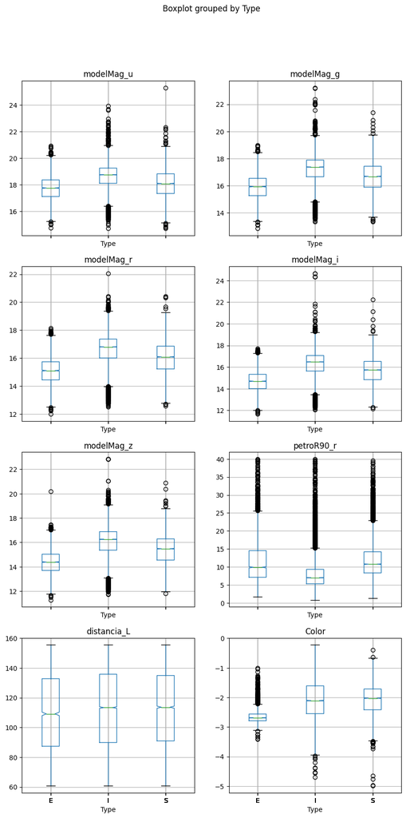

```python
fig, ax = plt.subplots(4, 2,sharex=True, figsize=(10, 20))
dataset.boxplot('modelMag_u','Type',notch=True, ax=ax[0][0])
dataset.boxplot('modelMag_g','Type',notch=True, ax=ax[0][1])
dataset.boxplot('modelMag_r','Type',notch=True, ax=ax[1][0])
dataset.boxplot('modelMag_i','Type',notch=True, ax=ax[1][1])
dataset.boxplot('modelMag_z','Type',notch=True, ax=ax[2][0])
dataset.boxplot('petroR90_r','Type',notch=True, ax=ax[2][1])
dataset.boxplot('distancia_L','Type', notch=True,ax=ax[3][0])
dataset.boxplot('Color','Type',notch=True, ax=ax[3][1])
```

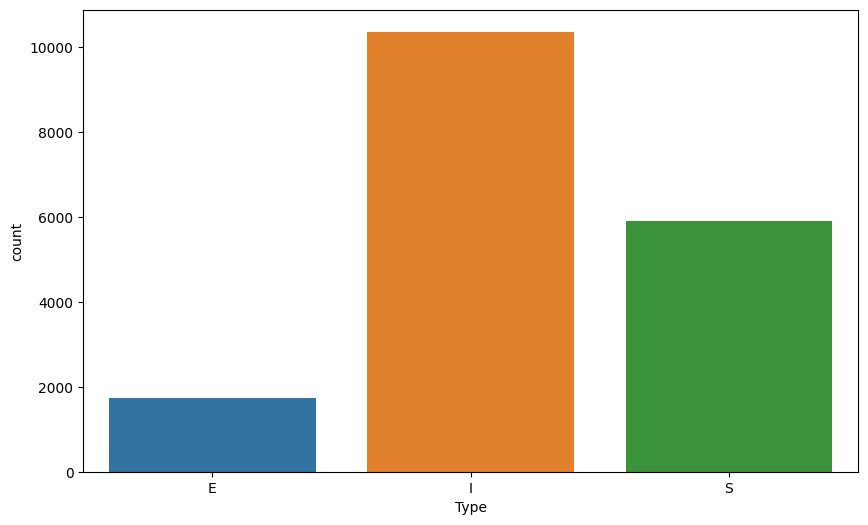

```python
sns.countplot(x=data_cl["Type"])
```

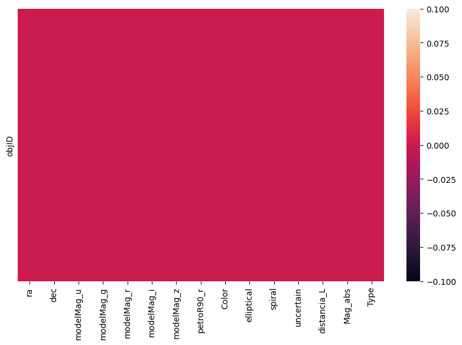

```python
sns.heatmap(data_cl.isna(), yticklabels=False)
```

```python
def distribution_per_type(df, col_name="", bins=20):
    plt.title(f"{col_name.capitalize()} Distribution")
    sns.distplot(df[df["elliptical"] == 1][col_name],label="elliptical", bins=bins)
    sns.distplot(df[df["spiral"] == 1][col_name],label="spiral", bins=bins)
    sns.distplot(df[df["uncertain"] == 1][col_name],label="irregular", bins=bins)
    plt.legend()

def exploratory_plots(df, col_name=""):
    plt.subplot(3, 1, 1)
    distribution_per_type(df, col_name)
    plt.subplot(3, 1, 2)
    plt.title(f"{col_name.capitalize()} Boxplot")
    sns.boxplot(x="Type", y=col_name, data=df)

    plt.subplot(3, 1, 3)
    plt.title(f"{col_name.capitalize()} Boxplot w/o Outliers")
    sns.boxplot(x="Type", y=col_name, data=df, showfliers=False)

    plt.tight_layout()
```

## Pair Plot

```python
data_cl.columns
```

```
Index(['ra', 'dec', 'modelMag_u', 'modelMag_g', 'modelMag_r', 'modelMag_i',
       'modelMag_z', 'petroR90_r', 'Color', 'elliptical', 'spiral',
       'uncertain', 'distancia_L', 'Mag_abs', 'Type'],
      dtype='object')
```

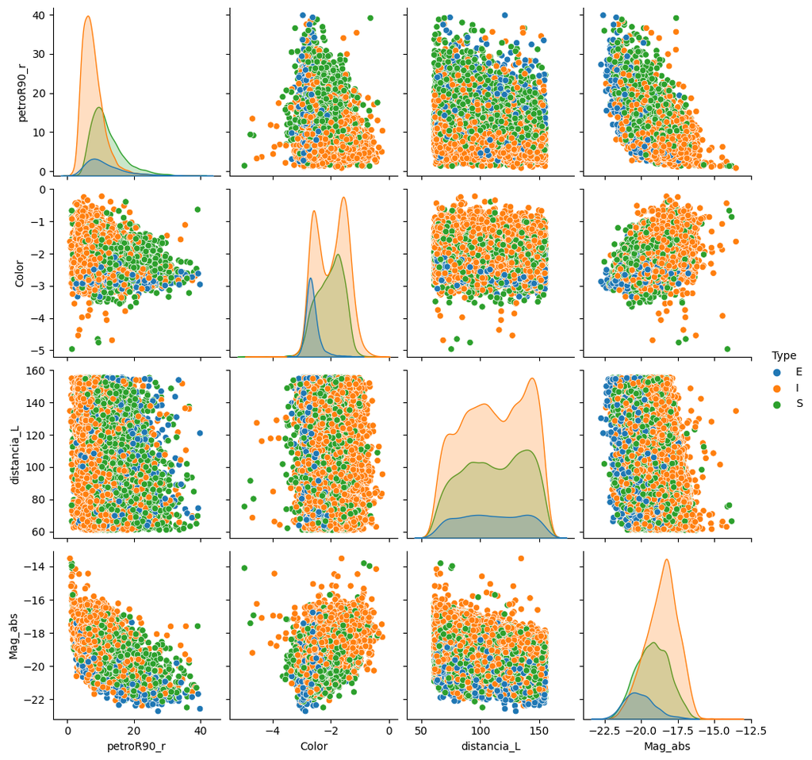

```python
plot_cols = ['petroR90_r', 'Color', 'distancia_L', 'Mag_abs', 'Type']
sns.pairplot(data_cl[plot_cols], hue="Type")
```

## Distancia L

[output not shown]

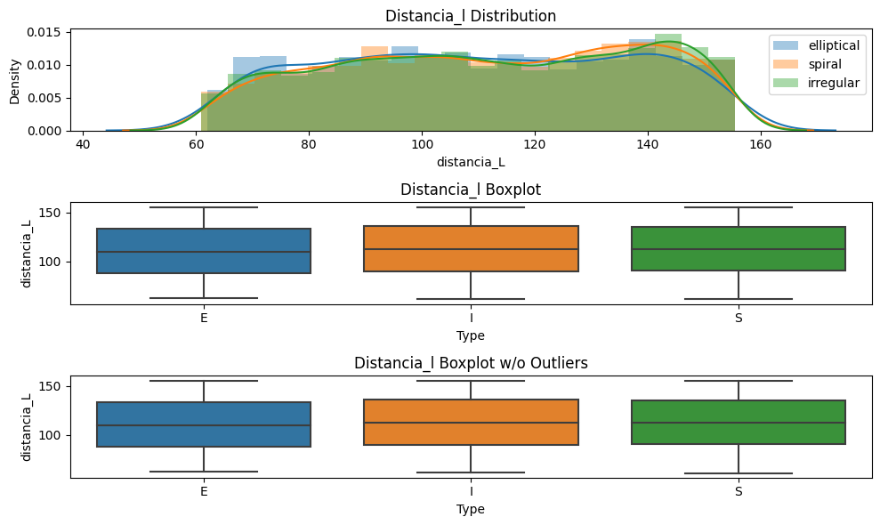

```python
exploratory_plots(data_cl, "distancia_L")
```

## Mag_abs

[output not shown]

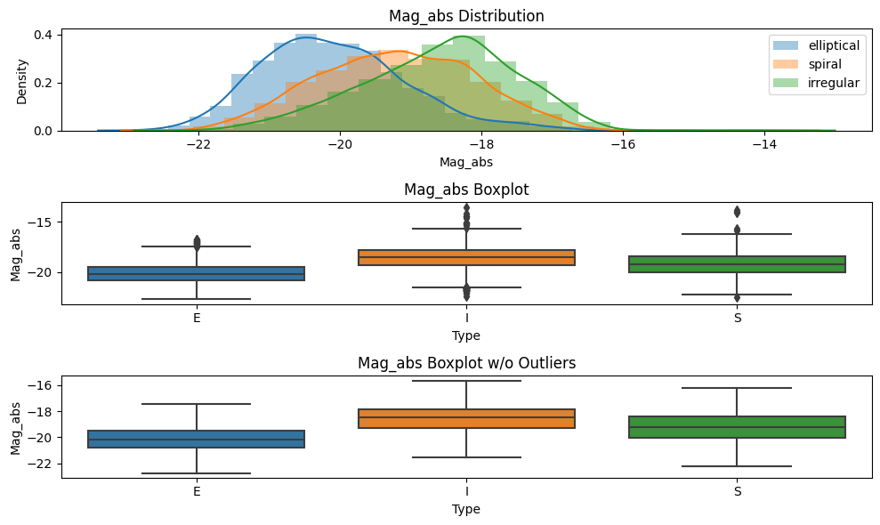

```python
exploratory_plots(data_cl, "Mag_abs")
```

**Que puede decir de las nuevas variables?**

La variable magnitud absoluta `'Mag_abs'` es una medida de su brillo intrínseco, o cuán brillante aparecería (medido en magnitud aparente) el objeto si estuviera ubicado a una distancia estándar de 10 parsecs (aproximadamente 32.6 años luz) de un observador. La magnitud absoluta de una galaxia se define midiendo toda la luz radiada por todo el objeto, tratando esa luminosidad integrada como la luminosidad de una fuente puntual o estelar, y calculando la magnitud de esa fuente puntual tal como aparecería si se observara a la distancia estándar de 10 parsecs. En consecuencia, la magnitud absoluta de cualquier objeto es igual a la magnitud aparente que tendría si estuviera a 10 parsecs de distancia.

La variable de distancia `'distancia_L'` es una medida de la distancia a la galaxia en cuestion, en unidades de megaparsec (3.2 millones de años luz aproximadamente)

# Regresión

Existe una relación empírica entre el radio efectivo (petro petroR90_r) y la magnitud absoluta para galaxias (datos de Bender et al. 1992, ApJ., 399, 462)

Por lo tanto, el valor a predecir sera **Mag_abs** la cual está contenida en un intervalo real de tamaño ~ 9mag, el atributo a usar sera el logaritmo en base diez de la variable **petroR90_r**.

**Detallar los pasos realizados (split, fit, metrica..) en el uso de el algoritmo de Regresión lineal con y sin regularización.**

E el algoritmo de regresion lineal se divide al dataset en 4 conjuntos diferentes x_train,y_train,x_test,y_test. x_train y y_train son los datos que se usan para realizar el entrenamiento, donde y_train son las etiquetas y x_train son los features. x_test y y_test se usan para realizar el test del modelo, donde nuevamente x_test son las features o input y y_test es la etiqueta real, que sirve para comparar la prediccion con el valor esperado. Esa comparacion se realiza utilizando metricas como pueden ser el error cuadratico medio MSE o el coeficiente R-squared, que determina la proporcion de la varianza que es explicada por la variable independiente, en este caso los features.

```python
data_cl["log_petroR90"] = np.log10(data_cl["petroR90_r"])
```

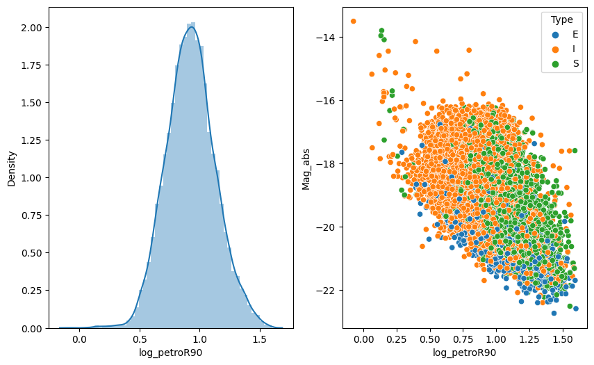

```python
f, axs = plt.subplots(1,2)
sns.distplot(data_cl["log_petroR90"], ax=axs[0])
sns.scatterplot(x="log_petroR90", y="Mag_abs", data=data_cl,hue="Type", ax=axs[1])
```

## Train / Validation / Test Split

```python
from sklearn.model_selection import train_test_split
from sklearn.preprocessing import StandardScaler
from sklearn.linear_model import LinearRegression, Lasso, Ridge
from sklearn.metrics import r2_score, mean_squared_error, f1_score
```

```python
X = data_cl["log_petroR90"]
y = data_cl["Mag_abs"]

X_train, X_test, y_train, y_test = train_test_split(X, y, test_size=0.2, random_state=42421)
X_train, X_test = X_train.values.reshape(-1,1), X_test.values.reshape(-1,1)
```

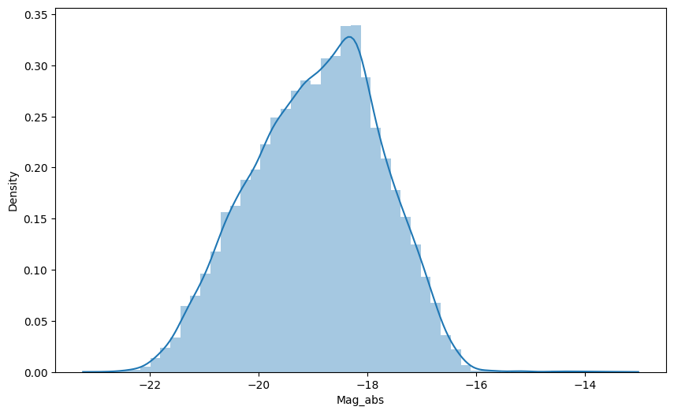

```python
sns.distplot(y)
```

```python
y.describe()
```

```
count    18007.000000
mean       -18.937537
std          1.184483
min        -22.730648
25%        -19.785564
50%        -18.858549
75%        -18.082197
max        -13.516647
Name: Mag_abs, dtype: float64
```

## Modelo Lineal y Regularización

Aca LinnearRegrassion() es una regresion normal sin penalizacion (regularizacion), donde se calculan los coeficientes del modelo minimizando la funcion de costo RSE (Residual Squared Error), la solucion es analitica y es exacta. Lasso() es un modelo de regresion lineal que incluye regularizaciones, añadiendole un termino extra al RSE llamado elemento de regularizacion L1. El objetivo de Lasso() es evitar que los pesos crezcan demasiado, buscando evitar overfitting.

```python
model = LinearRegression()
model.fit(X_train, y_train)

model_lasso = Lasso(alpha=0.01, random_state=4212)
model_lasso.fit(X_train, y_train)
#list(zip(X.columns, model.coef_))
```

```
Lasso(alpha=0.01, random_state=4212)
```

```python
y_pred = model.predict(X_test)
y_pred_lasso = model_lasso.predict(X_test)
```

```python
print("-"*80)
print("Linear Regression")
print("R2 Score: ", r2_score(y_test, y_pred))
print("MSE: ", mean_squared_error(y_test, y_pred))
print("SE:  ", mean_squared_error(y_test, y_pred) * y_test.shape[0])
print("-"*80)
print("Linear Regression with Lasso Regularization")
print("R2 Score: ", r2_score(y_test, y_pred_lasso))
print("MSE: ", mean_squared_error(y_test, y_pred_lasso))
print("SE:  ", mean_squared_error(y_test, y_pred_lasso) * y_test.shape[0])
```

```
--------------------------------------------------------------------------------
Linear Regression
R2 Score:  0.27899199700100696
MSE:  1.0034302380303863
SE:   3614.3557173854515
--------------------------------------------------------------------------------
Linear Regression with Lasso Regularization
R2 Score:  0.27612246786614336
MSE:  1.0074237752600075
SE:   3628.7404384865467
```

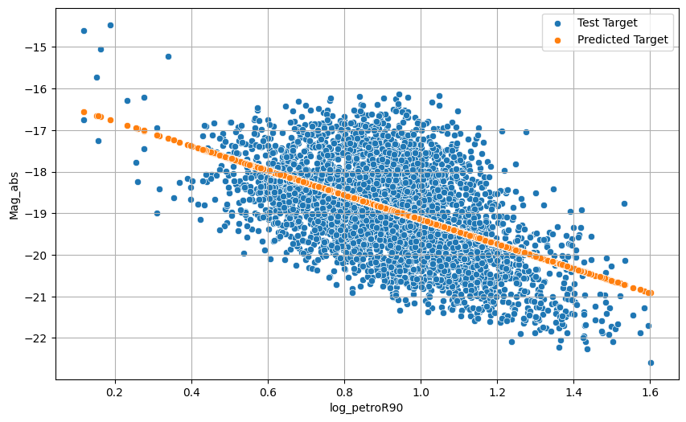

```python
sns.scatterplot(x=X_test.reshape(1,-1)[0], y=y_test, label="Test Target")
sns.scatterplot(x=X_test.reshape(1,-1)[0], y=y_pred, label="Predicted Target")
plt.xlabel("log_petroR90")
plt.legend()
plt.grid()
```

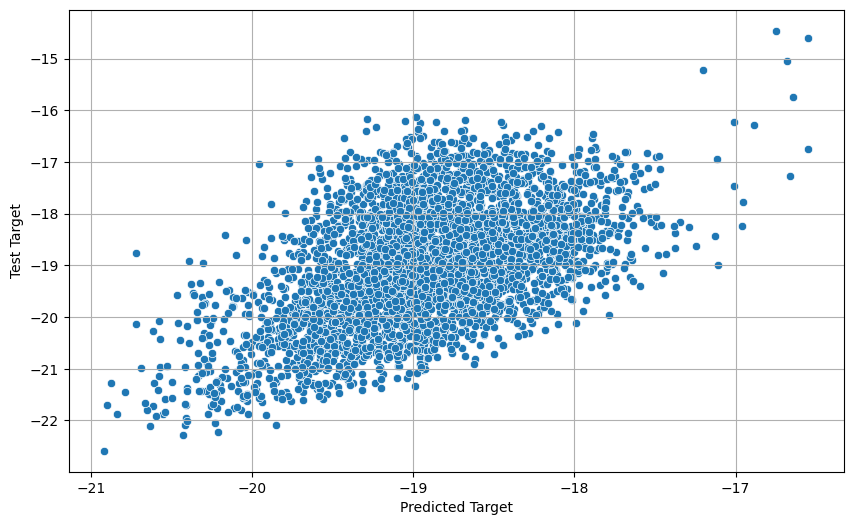

```python
sns.scatterplot(x=y_pred, y=y_test)
plt.xlabel("Predicted Target")
plt.ylabel("Test Target")
plt.grid()
```

## Modelo por tipo de galaxia

```python
X_d, y_d = {}, {}
X_train_d, X_test_d, y_train_d, y_test_d = {}, {}, {}, {}

for ttype in data_cl["Type"].unique():
    mask = data_cl["Type"] == ttype
    X_d[ttype] = data_cl[mask]["log_petroR90"]
    y_d[ttype] = data_cl[mask]["Mag_abs"]

    X_train_d[ttype], X_test_d[ttype], y_train_d[ttype], y_test_d[ttype] = \
    train_test_split(X_d[ttype], y_d[ttype], test_size=0.2, random_state=42421)
    X_train_d[ttype], X_test_d[ttype] = X_train_d[ttype].values.reshape(-1,1), X_test_d[ttype].values.reshape(-1,1)
```

```python
models = {}
y_pred_train_d = {}
y_pred_test_d  = {}
for ttype in data_cl["Type"].unique():
    models[ttype] = LinearRegression()
    models[ttype].fit(X_train_d[ttype], y_train_d[ttype])
    y_pred_train_d[ttype] = models[ttype].predict(X_train_d[ttype])
    y_pred_test_d[ttype] = models[ttype].predict(X_test_d[ttype])

for ttype in data_cl["Type"].unique():
    print("-"*80)
    print(ttype)
    print("-"*80)
    print("R2 Score: ", r2_score(y_test_d[ttype], y_pred_test_d[ttype]))
    print("MSE: ", mean_squared_error(y_test_d[ttype], y_pred_test_d[ttype]))
    print(models[ttype].coef_)
```

```
--------------------------------------------------------------------------------
E
--------------------------------------------------------------------------------
R2 Score:  0.4452439100100508
MSE:  0.632555350579261
[-3.32708517]
--------------------------------------------------------------------------------
I
--------------------------------------------------------------------------------
R2 Score:  0.14991644057874087
MSE:  1.038591271711517
[-2.08425229]
--------------------------------------------------------------------------------
S
--------------------------------------------------------------------------------
R2 Score:  0.2861847012598092
MSE:  0.8544626670983083
[-3.5546626]
```

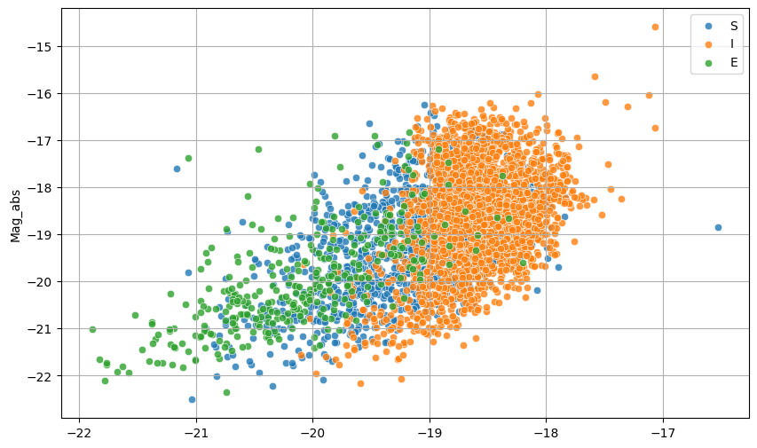

```python
for ttype in data_cl["Type"].unique()[::-1]:
    sns.scatterplot(x=y_pred_test_d[ttype], y=y_test_d[ttype], alpha=0.8, label=ttype)
    plt.grid()
    plt.legend()
```

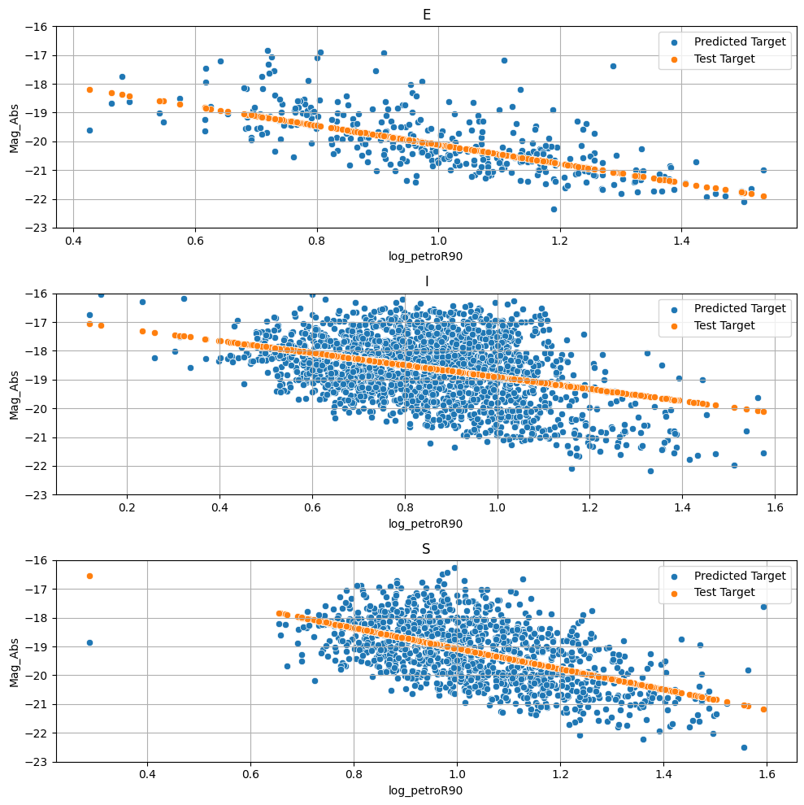

```python
f, axs = plt.subplots(3,1, figsize=(10,10))
for idx, ttype in enumerate(data_cl["Type"].unique()):
    sns.scatterplot(y=y_test_d[ttype],      x=X_test_d[ttype].reshape(1,-1)[0], ax=axs[idx],
                   label="Predicted Target")
    sns.scatterplot(y=y_pred_test_d[ttype], x=X_test_d[ttype].reshape(1,-1)[0], ax=axs[idx],
                    label="Test Target")

    axs[idx].set_xlabel("log_petroR90")
    axs[idx].set_ylabel("Mag_Abs")
    axs[idx].legend()
    axs[idx].grid()
    axs[idx].set_title(ttype)
    axs[idx].set_ylim([-23, -16])

plt.tight_layout()
```

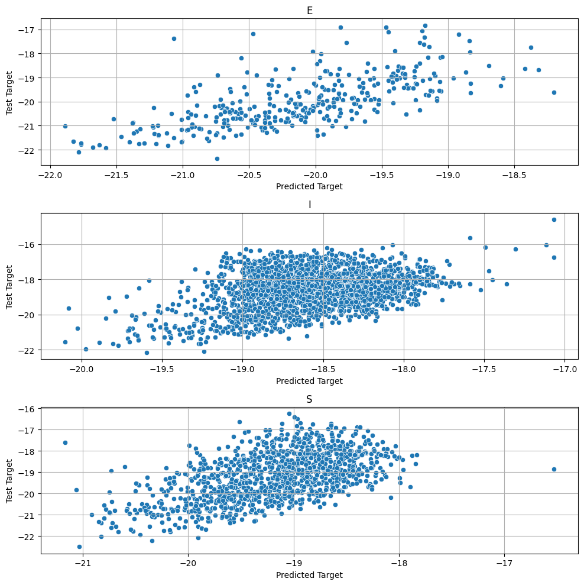

```python
f, axs = plt.subplots(3,1, figsize=(10,10))
for idx, ttype in enumerate(data_cl["Type"].unique()):
    sns.scatterplot(x=y_pred_test_d[ttype], y=y_test_d[ttype], ax=axs[idx])
    axs[idx].grid()
    axs[idx].set_title(ttype)
    axs[idx].set_xlabel("Predicted Target")
    axs[idx].set_ylabel("Test Target")
plt.tight_layout()
```

Responda:

- Que significa el error cuadrático?
- Que unidades tiene?
- Es necesaria la regularización?
- Es bueno valor obtenido en la métrica?
- Que pasa si se distingue por tipo de galaxia?